# Power Analysis for CSI online typing

Kirsten Stark

02 März, 2021

# load packages

```r
library(dplyr)
library(tidyr)
library(devtools)
library(MASS)
library(lme4)
library(lmerTest)
library(simr)
library(pbkrtest)
library(testthat)
```

```r
library(ggplot2)

rm(list = ls())
```

# load data from online verbal CSI experiment

```r
today <- Sys.Date()
today <- format(today, format="%d%m%y")

# load data
load(here::here("data_for_power_analysis","df.RData"))
df_online <- df

# subset the relevant columns
df_online <- df_online %>%
  filter(subcat_code != 100) %>%
  filter(correct == "1") %>%
  filter(VP != "31") %>%
  dplyr::select(c(VP, Pos, subcat, VOT)) %>%
  droplevels() %>%
  dplyr::rename(RT = VOT)

# factorize columns
is.numeric(df_online$RT)
```

```
## [1] TRUE
```

```r
df_online$VP <- as.factor(df_online$VP)
df_online$Pos <- as.factor(df_online$Pos)
df_online$category <- as.factor(df_online$subcat)
```

# load data from lab-based verbal CSI experiment

```r
# load data
load(here::here("data_for_power_analysis","CSI_model_df.RData"))
df_lab <- model_df

# subset relevant columns
df_lab <- df_lab %>%
  filter(Durchgang == 1) %>%
  filter(CatSize == 101) %>%
  dplyr::select(VPNr, OrdPos, UCatName, RT) %>%
  droplevels() %>%
  dplyr::rename(VP = VPNr, Pos = OrdPos, subcat = UCatName)

# factorize columns
is.numeric(df_lab$RT)
```

```
## [1] TRUE
```

```r
df_lab$VP <- as.factor(df_lab$VP)
df_lab$Pos <- as.factor(df_lab$Pos)
df_lab$category <- as.factor(df_lab$subcat)
```

# 1) Set up models based on structure of the online CSI experiments

1. Set polynomial contrasts for Pos (version with factorized predictor), and b) center Pos (version with continuous predictor)

```r
# set polynomial contrasts
contrasts(df_online$Pos) <- contr.poly(n = 5)
fixef_terms <- model.matrix( ~ Pos,df_online)
df_online$Pos.L <- fixef_terms[,2]

# center continuous predictor
df_online$Pos.c <- scale(as.numeric(as.character(df_online$Pos)), center = TRUE, scale = FALSE)
#df_online$Pos.c <- as.numeric(df_online$Pos)
```

2. Check distribution of RTs

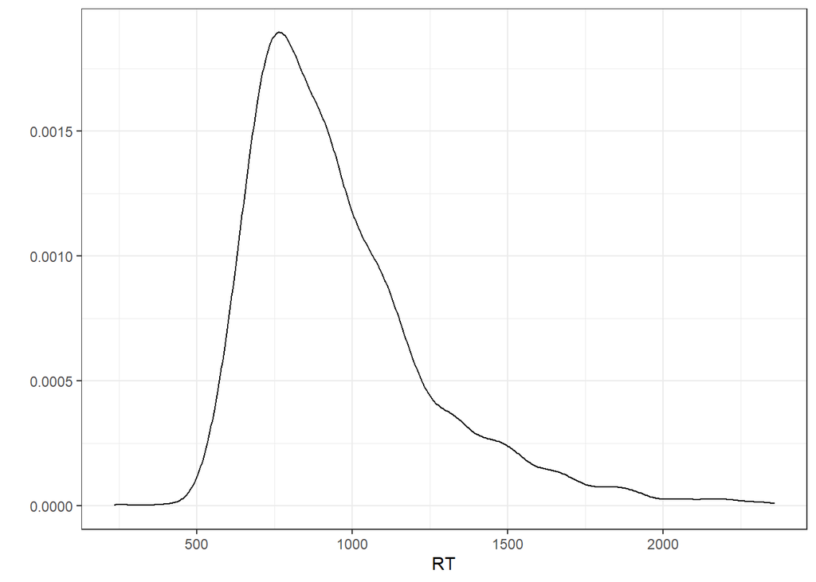

```r
# check distribution of RTs (by eyeballing)
# 1) density plot of RTs
qplot(data=df_online, RT, geom="density", na.rm=TRUE)+ theme_bw()
```

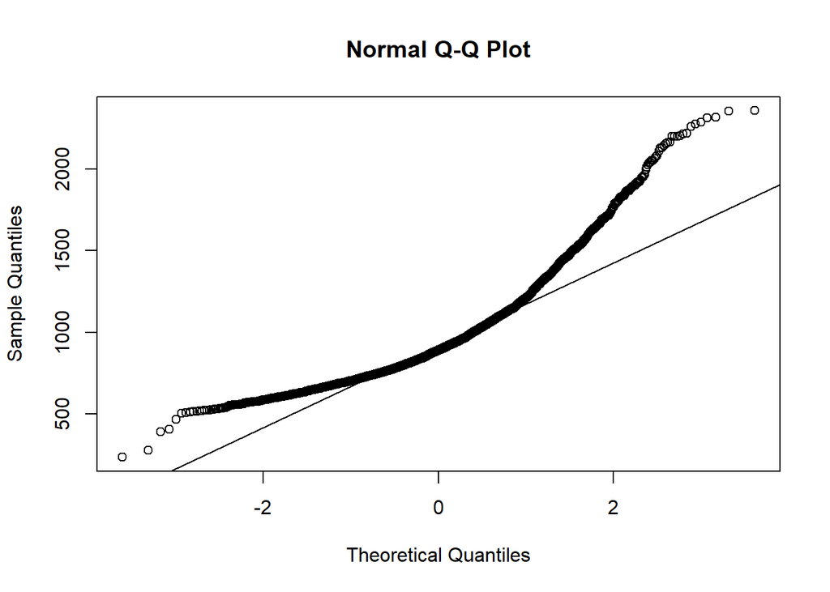

```r
# 2) plot data against real normal distribution -> is it way off?
qqnorm(df_online$RT); qqline(df_online$RT)
```

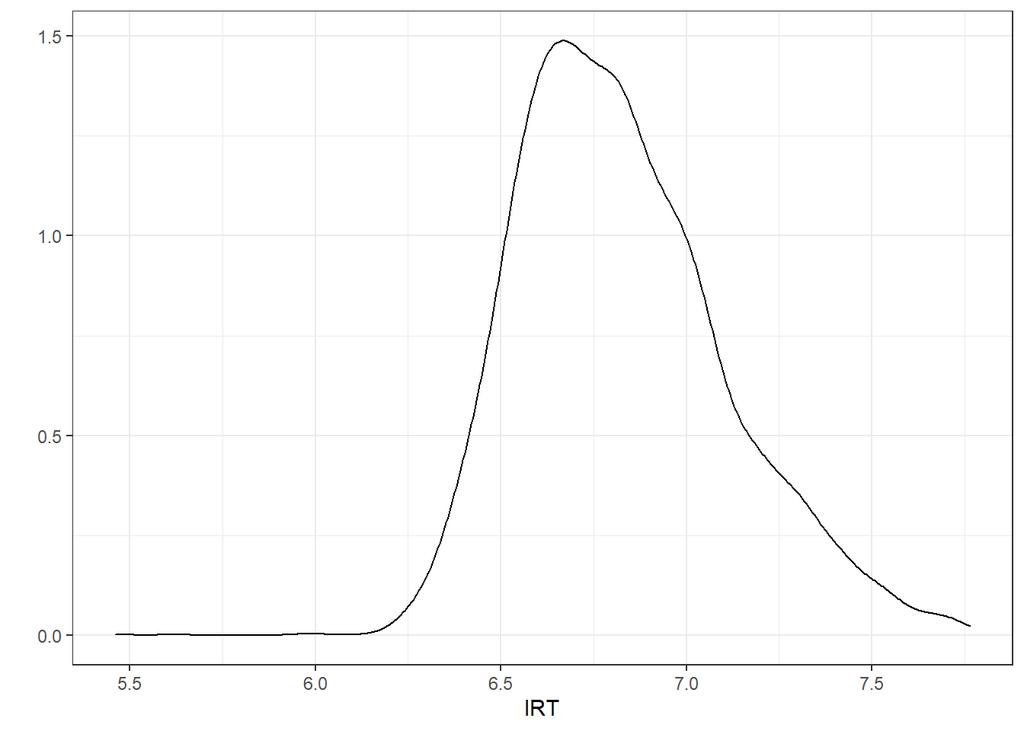

```r
# check distribution of logRTs (by eyeballing)
df_online$lRT <- log(df_online$RT)
# 1) density plot of logRTs
qplot(data=df_online, lRT, geom="density", na.rm=TRUE)+ theme_bw()
```

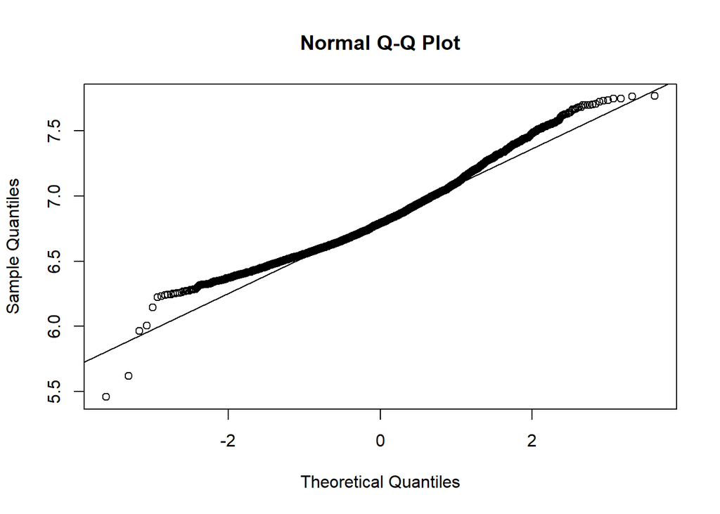

```r
# 2) plot data against real normal distribution -> is it way off?
qqnorm(df_online$lRT); qqline(df_online$lRT)
```

```r
### data kind of normally distributed. Log RTs fit better
```

3. Set up the models  
   *Model 1: Linear model, categorical predictor, untransformed RT data*

```r
# Model 1: Linear model with untransformed RT data
# lmm1 <- lmer(RT ~ Pos.L + (Pos.L|VP) +(Pos.L|subcat) ,
#             data = df_online, REML = FALSE,
#             control=lmerControl(optimizer = "bobyqa",
#             optCtrl = list(maxfun = 2*10^5)))
# isSingular(lmm1)
lmm1 <- lmer(RT ~ Pos.L + (1|VP) +(Pos.L|subcat) ,
            data = df_online, REML = FALSE,
            control=lmerControl(optimizer = "bobyqa",
            optCtrl = list(maxfun = 2*10^5)))
isSingular(lmm1)
```

```
## [1] FALSE
```

```r
summary(lmm1)
```

```
## Linear mixed model fit by maximum likelihood . t-tests use Satterthwaite's
##   method [lmerModLmerTest]
## Formula: RT ~ Pos.L + (1 | VP) + (Pos.L | subcat)
##    Data: df_online
## Control: lmerControl(optimizer = "bobyqa", optCtrl = list(maxfun = 2 *
##     10^5))
##
##      AIC      BIC   logLik deviance df.resid
##  46520.9  46563.6 -23253.4  46506.9     3298
##
## Scaled residuals:
##     Min      1Q  Median      3Q     Max
## -2.9782 -0.6397 -0.2160  0.3629  5.0255
##
## Random effects:
##  Groups   Name        Variance Std.Dev. Corr
##  VP       (Intercept)  9573     97.84
##  subcat   (Intercept)  4628     68.03
##           Pos.L        2848     53.36   0.21
##  Residual             72236    268.77
## Number of obs: 3305, groups:  VP, 30; subcat, 24
##
## Fixed effects:
##             Estimate Std. Error     df t value Pr(>|t|)
## (Intercept)   963.79      23.11  48.19  41.709  < 2e-16 ***
## Pos.L          47.73      15.13  23.87   3.154  0.00431 **
## ---
## Signif. codes:  0 '***' 0.001 '**' 0.01 '*' 0.05 '.' 0.1 ' ' 1
##
## Correlation of Fixed Effects:
##       (Intr)
## Pos.L 0.090
```

*Model 2: Linear model, categorical predictor, log-transformed RT data*

```r
# Model 2: Linear model with log transformed RT data
# lmm2_log <- lmer(lRT ~ Pos.L + (Pos.L|VP) +(Pos.L|subcat) ,
#             data = df_online, REML = FALSE,
#             control=lmerControl(optimizer = "bobyqa",
#             optCtrl = list(maxfun = 2*10^5)))
# isSingular(lmm2_log)
lmm1_log <- lmer(lRT ~ Pos.L + (1|VP) +(Pos.L|subcat) ,
            data = df_online, REML = FALSE,
            control=lmerControl(optimizer = "bobyqa",
            optCtrl = list(maxfun = 2*10^5)))
summary(lmm1_log)
```

```
## Linear mixed model fit by maximum likelihood . t-tests use Satterthwaite's
##   method [lmerModLmerTest]
## Formula: lRT ~ Pos.L + (1 | VP) + (Pos.L | subcat)
##    Data: df_online
## Control: lmerControl(optimizer = "bobyqa", optCtrl = list(maxfun = 2 *
##     10^5))
##
##      AIC      BIC   logLik deviance df.resid
##    402.9    445.6   -194.5    388.9     3298
##
## Scaled residuals:
##     Min      1Q  Median      3Q     Max
## -5.6915 -0.6608 -0.1322  0.5192  3.9189
##
## Random effects:
##  Groups   Name        Variance Std.Dev. Corr
##  VP       (Intercept) 0.010224 0.10112
##  subcat   (Intercept) 0.004790 0.06921
##           Pos.L       0.002424 0.04924  0.19
##  Residual             0.062717 0.25043
## Number of obs: 3305, groups:  VP, 30; subcat, 24
##
## Fixed effects:
##             Estimate Std. Error       df t value Pr(>|t|)
## (Intercept)  6.82948    0.02365 48.69705 288.730  < 2e-16 ***
## Pos.L        0.04607    0.01403 23.87477   3.284  0.00315 **
## ---
## Signif. codes:  0 '***' 0.001 '**' 0.01 '*' 0.05 '.' 0.1 ' ' 1
##
## Correlation of Fixed Effects:
##       (Intr)
## Pos.L 0.084
```

*Model 3: GLMM (Gamma distribution), categorical predictor, untransformed RT data*

```r
# Model 3: Generalized linear model with gamma distribution
glmm1 <- glmer(RT ~ Pos.L + (Pos.L|VP) +(Pos.L|subcat) ,
            data = df_online,  family =Gamma(link ="identity"),
            control=glmerControl(optimizer = "bobyqa"))
isSingular(glmm1)
```

```
## [1] FALSE
```

```r
summary(glmm1)
```

```
## Generalized linear mixed model fit by maximum likelihood (Laplace
##   Approximation) [glmerMod]
##  Family: Gamma  ( identity )
## Formula: RT ~ Pos.L + (Pos.L | VP) + (Pos.L | subcat)
##    Data: df_online
## Control: glmerControl(optimizer = "bobyqa")
##
##      AIC      BIC   logLik deviance df.resid
##  45630.5  45685.4 -22806.3  45612.5     3296
##
## Scaled residuals:
##     Min      1Q  Median      3Q     Max
## -2.7923 -0.6499 -0.2285  0.3832  5.4399
##
## Random effects:
##  Groups   Name        Variance  Std.Dev. Corr
##  VP       (Intercept) 3.517e+03 59.3061
##           Pos.L       1.489e+03 38.5897  0.08
##  subcat   (Intercept) 2.056e+03 45.3475
##           Pos.L       3.394e+03 58.2566  0.14
##  Residual             7.706e-02  0.2776
## Number of obs: 3305, groups:  VP, 30; subcat, 24
##
## Fixed effects:
##             Estimate Std. Error t value Pr(>|z|)
## (Intercept)  987.668      6.452 153.083  < 2e-16 ***
## Pos.L         50.547      8.183   6.177 6.54e-10 ***
## ---
## Signif. codes:  0 '***' 0.001 '**' 0.01 '*' 0.05 '.' 0.1 ' ' 1
##
## Correlation of Fixed Effects:
##       (Intr)
## Pos.L -0.108
```

*Model 4: Linear model, continuous predictor, untransformed RT data*

```r
# Model 4: Linear model with untransformed RT data
# lmm2 <- lmer(RT ~ Pos.c + (Pos.c|VP) +(Pos.c|subcat) ,
#             data = df_online, REML = FALSE,
#             control=lmerControl(optimizer = "bobyqa",
#             optCtrl = list(maxfun = 2*10^5)))
lmm2 <- lmer(RT ~ Pos.c + (1|VP) +(Pos.c|subcat) ,
            data = df_online, REML = FALSE,
            control=lmerControl(optimizer = "bobyqa",
                                optCtrl = list(maxfun = 2*10^5)))
isSingular(lmm2)
```

```
## [1] FALSE
```

```r
summary(lmm2)
```

```
## Linear mixed model fit by maximum likelihood . t-tests use Satterthwaite's
##   method [lmerModLmerTest]
## Formula: RT ~ Pos.c + (1 | VP) + (Pos.c | subcat)
##    Data: df_online
## Control: lmerControl(optimizer = "bobyqa", optCtrl = list(maxfun = 2 *
##     10^5))
##
##      AIC      BIC   logLik deviance df.resid
##  46520.9  46563.6 -23253.4  46506.9     3298
##
## Scaled residuals:
##     Min      1Q  Median      3Q     Max
## -2.9782 -0.6397 -0.2160  0.3629  5.0255
##
## Random effects:
##  Groups   Name        Variance Std.Dev. Corr
##  VP       (Intercept)  9573.3   97.84
##  subcat   (Intercept)  4622.7   67.99
##           Pos.c         284.8   16.87   0.20
##  Residual             72235.7  268.77
## Number of obs: 3305, groups:  VP, 30; subcat, 24
##
## Fixed effects:
##             Estimate Std. Error      df t value Pr(>|t|)
## (Intercept)  963.607     23.103  48.181  41.710  < 2e-16 ***
## Pos.c         15.094      4.785  23.869   3.154  0.00431 **
## ---
## Signif. codes:  0 '***' 0.001 '**' 0.01 '*' 0.05 '.' 0.1 ' ' 1
##
## Correlation of Fixed Effects:
##       (Intr)
## Pos.c 0.088
```

*Model 5: Linear model, continuous predictor, log-transformed RT data*

```r
# Model 5: Linear model with log- RT data
# lmm2_log <- lmer(lRT ~ Pos.c + (Pos.c|VP) +(Pos.c|subcat) ,
#             data = df_online, REML = FALSE,
#             control=lmerControl(optimizer = "bobyqa",
#             optCtrl = list(maxfun = 2*10^5)))
lmm2_log <- lmer(lRT ~ Pos.c + (1|VP) +(Pos.c|subcat) ,
            data = df_online, REML = FALSE,
            control=lmerControl(optimizer = "bobyqa",
            optCtrl = list(maxfun = 2*10^5)))
isSingular(lmm2_log)
```

```
## [1] FALSE
```

```r
summary(lmm2_log)
```

```
## Linear mixed model fit by maximum likelihood . t-tests use Satterthwaite's
##   method [lmerModLmerTest]
## Formula: lRT ~ Pos.c + (1 | VP) + (Pos.c | subcat)
##    Data: df_online
## Control: lmerControl(optimizer = "bobyqa", optCtrl = list(maxfun = 2 *
##     10^5))
##
##      AIC      BIC   logLik deviance df.resid
##    402.9    445.6   -194.5    388.9     3298
##
## Scaled residuals:
##     Min      1Q  Median      3Q     Max
## -5.6915 -0.6608 -0.1322  0.5192  3.9189
##
## Random effects:
##  Groups   Name        Variance  Std.Dev. Corr
##  VP       (Intercept) 0.0102243 0.10112
##  subcat   (Intercept) 0.0047846 0.06917
##           Pos.c       0.0002424 0.01557  0.19
##  Residual             0.0627166 0.25043
## Number of obs: 3305, groups:  VP, 30; subcat, 24
##
## Fixed effects:
##              Estimate Std. Error        df t value Pr(>|t|)
## (Intercept)  6.829300   0.023649 48.688700 288.777  < 2e-16 ***
## Pos.c        0.014567   0.004436 23.874756   3.284  0.00315 **
## ---
## Signif. codes:  0 '***' 0.001 '**' 0.01 '*' 0.05 '.' 0.1 ' ' 1
##
## Correlation of Fixed Effects:
##       (Intr)
## Pos.c 0.082
```

*Model 6: GLMM (Gamma distribution), continuous predictor, untransformed RT data*

```r
# Model 6: Generalized linear model with gamma distribution
glmm2 <- glmer(RT ~ Pos.c + (1|VP) +(1|subcat) ,
            data = df_online,  family =Gamma(link ="identity"),
            control=glmerControl(optimizer = "bobyqa"))
isSingular(glmm2)
```

```
## [1] FALSE
```

```r
summary(glmm2)
```

```
## Generalized linear mixed model fit by maximum likelihood (Laplace
##   Approximation) [glmerMod]
##  Family: Gamma  ( identity )
## Formula: RT ~ Pos.c + (1 | VP) + (1 | subcat)
##    Data: df_online
## Control: glmerControl(optimizer = "bobyqa")
##
##      AIC      BIC   logLik deviance df.resid
##  45657.3  45687.9 -22823.7  45647.3     3300
##
## Scaled residuals:
##     Min      1Q  Median      3Q     Max
## -2.7211 -0.6515 -0.2254  0.3725  5.5859
##
## Random effects:
##  Groups   Name        Variance  Std.Dev.
##  VP       (Intercept) 3.533e+03 59.44
##  subcat   (Intercept) 2.065e+03 45.44
##  Residual             7.839e-02  0.28
## Number of obs: 3305, groups:  VP, 30; subcat, 24
##
## Fixed effects:
##             Estimate Std. Error t value Pr(>|z|)
## (Intercept)  985.858      7.082 139.201  < 2e-16 ***
## Pos.c         14.139      2.884   4.902  9.5e-07 ***
## ---
## Signif. codes:  0 '***' 0.001 '**' 0.01 '*' 0.05 '.' 0.1 ' ' 1
##
## Correlation of Fixed Effects:
##       (Intr)
## Pos.c -0.023
```

#2) Extend dataset

```r
lmm1_2 <- extend(lmm1, along="VP", n=40)
m2data <- getData(lmm1_2)
## ok, data were indeed extended to n subjects ;-)
str(m2data)
```

```
## 'data.frame':    4409 obs. of  8 variables:
##  $ VP      : Factor w/ 40 levels "a","b","c","d",..: 1 1 1 1 1 1 1 1 1 1 ...
##  $ Pos     : Factor w/ 5 levels "1","2","3","4",..: 5 1 4 4 5 5 5 1 5 2 ...
##   ..- attr(*, "contrasts")= num [1:5, 1:4] -0.632 -0.316 0 0.316 0.632 ...
##   .. ..- attr(*, "dimnames")=List of 2
##   .. .. ..$ : chr [1:5] "1" "2" "3" "4" ...
##   .. .. ..$ : chr [1:4] ".L" ".Q" ".C" "^4"
##  $ subcat  : Factor w/ 24 levels "Aufbewahrung",..: 5 10 16 14 18 20 2 16 19 17 ...
##  $ RT      : num  920 763 616 731 1036 ...
##  $ category: Factor w/ 24 levels "Aufbewahrung",..: 5 10 16 14 18 20 2 16 19 17 ...
##  $ Pos.L   : num  0.632 -0.632 0.316 0.316 0.632 ...
##  $ Pos.c   : num [1:4409, 1] 2.01 -1.99 1.01 1.01 2.01 ...
##   ..- attr(*, "dimnames")=List of 2
##   .. ..$ : NULL
##   .. ..$ : NULL
##  $ lRT     : num  6.82 6.64 6.42 6.59 6.94 ...
```

```r
str(df_online)
```

```
## 'data.frame':    3305 obs. of  8 variables:
##  $ VP      : Factor w/ 30 levels "1","2","3","4",..: 1 1 1 1 1 1 1 1 1 1 ...
##  $ Pos     : Factor w/ 5 levels "1","2","3","4",..: 5 1 4 4 5 5 5 1 5 2 ...
##   ..- attr(*, "contrasts")= num [1:5, 1:4] -0.632 -0.316 0 0.316 0.632 ...
##   .. ..- attr(*, "dimnames")=List of 2
##   .. .. ..$ : chr [1:5] "1" "2" "3" "4" ...
##   .. .. ..$ : chr [1:4] ".L" ".Q" ".C" "^4"
##  $ subcat  : Factor w/ 24 levels "Aufbewahrung",..: 5 10 16 14 18 20 2 16 19 17 ...
##  $ RT      : num  920 763 616 731 1036 ...
##  $ category: Factor w/ 24 levels "Aufbewahrung",..: 5 10 16 14 18 20 2 16 19 17 ...
##  $ Pos.L   : num  0.632 -0.632 0.316 0.316 0.632 ...
##  $ Pos.c   : num [1:3305, 1] 2.01 -1.99 1.01 1.01 2.01 ...
##   ..- attr(*, "scaled:center")= num 2.99
##  $ lRT     : num  6.82 6.64 6.42 6.59 6.94 ...
```

```r
lmm1_2_log <- extend(lmm1_log, along="VP", n=40)
m2data <- getData(lmm1_2_log)
## ok, data were indeed extended to n subjects ;-)
str(m2data)
```

```
## 'data.frame':    4409 obs. of  8 variables:
##  $ VP      : Factor w/ 40 levels "a","b","c","d",..: 1 1 1 1 1 1 1 1 1 1 ...
##  $ Pos     : Factor w/ 5 levels "1","2","3","4",..: 5 1 4 4 5 5 5 1 5 2 ...
##   ..- attr(*, "contrasts")= num [1:5, 1:4] -0.632 -0.316 0 0.316 0.632 ...
##   .. ..- attr(*, "dimnames")=List of 2
##   .. .. ..$ : chr [1:5] "1" "2" "3" "4" ...
##   .. .. ..$ : chr [1:4] ".L" ".Q" ".C" "^4"
##  $ subcat  : Factor w/ 24 levels "Aufbewahrung",..: 5 10 16 14 18 20 2 16 19 17 ...
##  $ RT      : num  920 763 616 731 1036 ...
##  $ category: Factor w/ 24 levels "Aufbewahrung",..: 5 10 16 14 18 20 2 16 19 17 ...
##  $ Pos.L   : num  0.632 -0.632 0.316 0.316 0.632 ...
##  $ Pos.c   : num [1:4409, 1] 2.01 -1.99 1.01 1.01 2.01 ...
##   ..- attr(*, "dimnames")=List of 2
##   .. ..$ : NULL
##   .. ..$ : NULL
##  $ lRT     : num  6.82 6.64 6.42 6.59 6.94 ...
```

```r
str(df_online)
```

```
## 'data.frame':    3305 obs. of  8 variables:
##  $ VP      : Factor w/ 30 levels "1","2","3","4",..: 1 1 1 1 1 1 1 1 1 1 ...
##  $ Pos     : Factor w/ 5 levels "1","2","3","4",..: 5 1 4 4 5 5 5 1 5 2 ...
##   ..- attr(*, "contrasts")= num [1:5, 1:4] -0.632 -0.316 0 0.316 0.632 ...
##   .. ..- attr(*, "dimnames")=List of 2
##   .. .. ..$ : chr [1:5] "1" "2" "3" "4" ...
##   .. .. ..$ : chr [1:4] ".L" ".Q" ".C" "^4"
##  $ subcat  : Factor w/ 24 levels "Aufbewahrung",..: 5 10 16 14 18 20 2 16 19 17 ...
##  $ RT      : num  920 763 616 731 1036 ...
##  $ category: Factor w/ 24 levels "Aufbewahrung",..: 5 10 16 14 18 20 2 16 19 17 ...
##  $ Pos.L   : num  0.632 -0.632 0.316 0.316 0.632 ...
##  $ Pos.c   : num [1:3305, 1] 2.01 -1.99 1.01 1.01 2.01 ...
##   ..- attr(*, "scaled:center")= num 2.99
##  $ lRT     : num  6.82 6.64 6.42 6.59 6.94 ...
```

```r
glmm1_2<- extend(glmm1, along="VP", n=40)
m2data <- getData(glmm1)
## ok, data were indeed extended to n subjects ;-)
str(m2data)
```

```
## 'data.frame':    3305 obs. of  8 variables:
##  $ VP      : Factor w/ 30 levels "1","2","3","4",..: 1 1 1 1 1 1 1 1 1 1 ...
##  $ Pos     : Factor w/ 5 levels "1","2","3","4",..: 5 1 4 4 5 5 5 1 5 2 ...
##   ..- attr(*, "contrasts")= num [1:5, 1:4] -0.632 -0.316 0 0.316 0.632 ...
##   .. ..- attr(*, "dimnames")=List of 2
##   .. .. ..$ : chr [1:5] "1" "2" "3" "4" ...
##   .. .. ..$ : chr [1:4] ".L" ".Q" ".C" "^4"
##  $ subcat  : Factor w/ 24 levels "Aufbewahrung",..: 5 10 16 14 18 20 2 16 19 17 ...
##  $ RT      : num  920 763 616 731 1036 ...
##  $ category: Factor w/ 24 levels "Aufbewahrung",..: 5 10 16 14 18 20 2 16 19 17 ...
##  $ Pos.L   : num  0.632 -0.632 0.316 0.316 0.632 ...
##  $ Pos.c   : num [1:3305, 1] 2.01 -1.99 1.01 1.01 2.01 ...
##   ..- attr(*, "scaled:center")= num 2.99
##  $ lRT     : num  6.82 6.64 6.42 6.59 6.94 ...
```

```r
str(df_online)
```

```
## 'data.frame':    3305 obs. of  8 variables:
##  $ VP      : Factor w/ 30 levels "1","2","3","4",..: 1 1 1 1 1 1 1 1 1 1 ...
##  $ Pos     : Factor w/ 5 levels "1","2","3","4",..: 5 1 4 4 5 5 5 1 5 2 ...
##   ..- attr(*, "contrasts")= num [1:5, 1:4] -0.632 -0.316 0 0.316 0.632 ...
##   .. ..- attr(*, "dimnames")=List of 2
##   .. .. ..$ : chr [1:5] "1" "2" "3" "4" ...
##   .. .. ..$ : chr [1:4] ".L" ".Q" ".C" "^4"
##  $ subcat  : Factor w/ 24 levels "Aufbewahrung",..: 5 10 16 14 18 20 2 16 19 17 ...
##  $ RT      : num  920 763 616 731 1036 ...
##  $ category: Factor w/ 24 levels "Aufbewahrung",..: 5 10 16 14 18 20 2 16 19 17 ...
##  $ Pos.L   : num  0.632 -0.632 0.316 0.316 0.632 ...
##  $ Pos.c   : num [1:3305, 1] 2.01 -1.99 1.01 1.01 2.01 ...
##   ..- attr(*, "scaled:center")= num 2.99
##  $ lRT     : num  6.82 6.64 6.42 6.59 6.94 ...
```

```r
lmm2_2 <- extend(lmm2, along="VP", n=40)
m2data <- getData(lmm2_2)
## ok, data were indeed extended to n subjects ;-)
str(m2data)
```

```
## 'data.frame':    4409 obs. of  8 variables:
##  $ VP      : Factor w/ 40 levels "a","b","c","d",..: 1 1 1 1 1 1 1 1 1 1 ...
##  $ Pos     : Factor w/ 5 levels "1","2","3","4",..: 5 1 4 4 5 5 5 1 5 2 ...
##   ..- attr(*, "contrasts")= num [1:5, 1:4] -0.632 -0.316 0 0.316 0.632 ...
##   .. ..- attr(*, "dimnames")=List of 2
##   .. .. ..$ : chr [1:5] "1" "2" "3" "4" ...
##   .. .. ..$ : chr [1:4] ".L" ".Q" ".C" "^4"
##  $ subcat  : Factor w/ 24 levels "Aufbewahrung",..: 5 10 16 14 18 20 2 16 19 17 ...
##  $ RT      : num  920 763 616 731 1036 ...
##  $ category: Factor w/ 24 levels "Aufbewahrung",..: 5 10 16 14 18 20 2 16 19 17 ...
##  $ Pos.L   : num  0.632 -0.632 0.316 0.316 0.632 ...
##  $ Pos.c   : num [1:4409, 1] 2.01 -1.99 1.01 1.01 2.01 ...
##   ..- attr(*, "dimnames")=List of 2
##   .. ..$ : NULL
##   .. ..$ : NULL
##  $ lRT     : num  6.82 6.64 6.42 6.59 6.94 ...
```

```r
str(df_online)
```

```
## 'data.frame':    3305 obs. of  8 variables:
##  $ VP      : Factor w/ 30 levels "1","2","3","4",..: 1 1 1 1 1 1 1 1 1 1 ...
##  $ Pos     : Factor w/ 5 levels "1","2","3","4",..: 5 1 4 4 5 5 5 1 5 2 ...
##   ..- attr(*, "contrasts")= num [1:5, 1:4] -0.632 -0.316 0 0.316 0.632 ...
##   .. ..- attr(*, "dimnames")=List of 2
##   .. .. ..$ : chr [1:5] "1" "2" "3" "4" ...
##   .. .. ..$ : chr [1:4] ".L" ".Q" ".C" "^4"
##  $ subcat  : Factor w/ 24 levels "Aufbewahrung",..: 5 10 16 14 18 20 2 16 19 17 ...
##  $ RT      : num  920 763 616 731 1036 ...
##  $ category: Factor w/ 24 levels "Aufbewahrung",..: 5 10 16 14 18 20 2 16 19 17 ...
##  $ Pos.L   : num  0.632 -0.632 0.316 0.316 0.632 ...
##  $ Pos.c   : num [1:3305, 1] 2.01 -1.99 1.01 1.01 2.01 ...
##   ..- attr(*, "scaled:center")= num 2.99
##  $ lRT     : num  6.82 6.64 6.42 6.59 6.94 ...
```

```r
lmm2_2_log <- extend(lmm2_log, along="VP", n=40)
m2data <- getData(lmm2_2_log)
## ok, data were indeed extended to n subjects ;-)
str(m2data)
```

```
## 'data.frame':    4409 obs. of  8 variables:
##  $ VP      : Factor w/ 40 levels "a","b","c","d",..: 1 1 1 1 1 1 1 1 1 1 ...
##  $ Pos     : Factor w/ 5 levels "1","2","3","4",..: 5 1 4 4 5 5 5 1 5 2 ...
##   ..- attr(*, "contrasts")= num [1:5, 1:4] -0.632 -0.316 0 0.316 0.632 ...
##   .. ..- attr(*, "dimnames")=List of 2
##   .. .. ..$ : chr [1:5] "1" "2" "3" "4" ...
##   .. .. ..$ : chr [1:4] ".L" ".Q" ".C" "^4"
##  $ subcat  : Factor w/ 24 levels "Aufbewahrung",..: 5 10 16 14 18 20 2 16 19 17 ...
##  $ RT      : num  920 763 616 731 1036 ...
##  $ category: Factor w/ 24 levels "Aufbewahrung",..: 5 10 16 14 18 20 2 16 19 17 ...
##  $ Pos.L   : num  0.632 -0.632 0.316 0.316 0.632 ...
##  $ Pos.c   : num [1:4409, 1] 2.01 -1.99 1.01 1.01 2.01 ...
##   ..- attr(*, "dimnames")=List of 2
##   .. ..$ : NULL
##   .. ..$ : NULL
##  $ lRT     : num  6.82 6.64 6.42 6.59 6.94 ...
```

```r
str(df_online)
```

```
## 'data.frame':    3305 obs. of  8 variables:
##  $ VP      : Factor w/ 30 levels "1","2","3","4",..: 1 1 1 1 1 1 1 1 1 1 ...
##  $ Pos     : Factor w/ 5 levels "1","2","3","4",..: 5 1 4 4 5 5 5 1 5 2 ...
##   ..- attr(*, "contrasts")= num [1:5, 1:4] -0.632 -0.316 0 0.316 0.632 ...
##   .. ..- attr(*, "dimnames")=List of 2
##   .. .. ..$ : chr [1:5] "1" "2" "3" "4" ...
##   .. .. ..$ : chr [1:4] ".L" ".Q" ".C" "^4"
##  $ subcat  : Factor w/ 24 levels "Aufbewahrung",..: 5 10 16 14 18 20 2 16 19 17 ...
##  $ RT      : num  920 763 616 731 1036 ...
##  $ category: Factor w/ 24 levels "Aufbewahrung",..: 5 10 16 14 18 20 2 16 19 17 ...
##  $ Pos.L   : num  0.632 -0.632 0.316 0.316 0.632 ...
##  $ Pos.c   : num [1:3305, 1] 2.01 -1.99 1.01 1.01 2.01 ...
##   ..- attr(*, "scaled:center")= num 2.99
##  $ lRT     : num  6.82 6.64 6.42 6.59 6.94 ...
```

```r
glmm2_2<- extend(glmm2, along="VP", n=40)
m2data <- getData(glmm2_2)
## ok, data were indeed extended to n subjects ;-)
str(m2data)
```

```
## 'data.frame':    4409 obs. of  8 variables:
##  $ VP      : Factor w/ 40 levels "a","b","c","d",..: 1 1 1 1 1 1 1 1 1 1 ...
##  $ Pos     : Factor w/ 5 levels "1","2","3","4",..: 5 1 4 4 5 5 5 1 5 2 ...
##   ..- attr(*, "contrasts")= num [1:5, 1:4] -0.632 -0.316 0 0.316 0.632 ...
##   .. ..- attr(*, "dimnames")=List of 2
##   .. .. ..$ : chr [1:5] "1" "2" "3" "4" ...
##   .. .. ..$ : chr [1:4] ".L" ".Q" ".C" "^4"
##  $ subcat  : Factor w/ 24 levels "Aufbewahrung",..: 5 10 16 14 18 20 2 16 19 17 ...
##  $ RT      : num  920 763 616 731 1036 ...
##  $ category: Factor w/ 24 levels "Aufbewahrung",..: 5 10 16 14 18 20 2 16 19 17 ...
##  $ Pos.L   : num  0.632 -0.632 0.316 0.316 0.632 ...
##  $ Pos.c   : num [1:4409, 1] 2.01 -1.99 1.01 1.01 2.01 ...
##   ..- attr(*, "dimnames")=List of 2
##   .. ..$ : NULL
##   .. ..$ : NULL
##  $ lRT     : num  6.82 6.64 6.42 6.59 6.94 ...
```

```r
str(df_online)
```

```
## 'data.frame':    3305 obs. of  8 variables:
##  $ VP      : Factor w/ 30 levels "1","2","3","4",..: 1 1 1 1 1 1 1 1 1 1 ...
##  $ Pos     : Factor w/ 5 levels "1","2","3","4",..: 5 1 4 4 5 5 5 1 5 2 ...
##   ..- attr(*, "contrasts")= num [1:5, 1:4] -0.632 -0.316 0 0.316 0.632 ...
##   .. ..- attr(*, "dimnames")=List of 2
##   .. .. ..$ : chr [1:5] "1" "2" "3" "4" ...
##   .. .. ..$ : chr [1:4] ".L" ".Q" ".C" "^4"
##  $ subcat  : Factor w/ 24 levels "Aufbewahrung",..: 5 10 16 14 18 20 2 16 19 17 ...
##  $ RT      : num  920 763 616 731 1036 ...
##  $ category: Factor w/ 24 levels "Aufbewahrung",..: 5 10 16 14 18 20 2 16 19 17 ...
##  $ Pos.L   : num  0.632 -0.632 0.316 0.316 0.632 ...
##  $ Pos.c   : num [1:3305, 1] 2.01 -1.99 1.01 1.01 2.01 ...
##   ..- attr(*, "scaled:center")= num 2.99
##  $ lRT     : num  6.82 6.64 6.42 6.59 6.94 ...
```

#3) Specify effect sizes As shown below, the online effect size is somewhat smaller than the lab-based effect size. Therefore, we use the fixed effect from the verbal online study for each of the models:

Set up the same models for the lab-based experiment and compare effect sizes between online and lab experiments

```r
# set polynomial contrasts
contrasts(df_lab$Pos) <- contr.poly(n = 6)
fixef_terms <- model.matrix( ~ Pos,df_lab)
df_lab$Pos.L <- fixef_terms[,2]

# center continuous predictor
df_lab$Pos.c <- scale(as.numeric(as.character(df_lab$Pos)), center = TRUE, scale = FALSE)
```

*Model 1: Linear model, categorical predictor, untransformed RT data*

```r
# compare fixed effects between lab and online
fixef(lmm1_2)
```

```
## (Intercept)       Pos.L
##   963.78973    47.73269
```

```r
fixef(lmer(RT ~ Pos.L + (1|VP) +(Pos.L|subcat) ,
            data = df_lab, REML = FALSE,
            control=lmerControl(optimizer = "bobyqa",
            optCtrl = list(maxfun = 2*10^5))))
```

```
## (Intercept)       Pos.L
##  1035.81080    78.97718
```

```r
# use the smaller effect from the online study: 47.73269
fixef(lmm1_2)["Pos.L"] <- 47.73269
```

*Model 2: Linear model, categorical predictor, log-transformed RT data*

```r
# compare fixed effects between lab and online
# add log RTs
fixef(lmm1_2_log)
```

```
## (Intercept)       Pos.L
##  6.82947650  0.04606618
```

```r
df_lab$lRT <- log(df_lab$RT)
fixef(lmer(lRT ~ Pos.L + (1|VP) +(Pos.L|subcat) ,
            data = df_lab, REML = FALSE,
            control=lmerControl(optimizer = "bobyqa",
            optCtrl = list(maxfun = 2*10^5))))
```

```
## (Intercept)       Pos.L
##  6.90269385  0.07619018
```

```r
# use the smaller effect from the online study: 0.04606618
fixef(lmm1_2_log)["Pos.L"] <- 0.04606618
```

*Model 3: GLMM (Gamma distribution), categorical predictor, untransformed RT data*

```r
# compare fixed effects between lab and online
fixef(glmm1_2)
```

```
## (Intercept)       Pos.L
##   987.66826    50.54676
```

```r
  # reduced GLMM because model with lab-based data failed to converge
fixef(glmer(RT ~ Pos.L + (1|VP) +(Pos.L|subcat) ,
            data = df_lab,  family =Gamma(link ="identity"),
            control=glmerControl(optimizer = "bobyqa")))
```

```
## (Intercept)       Pos.L
##  1084.22283    82.79576
```

```r
# use the smaller effect from the online study: 50.54676
fixef(glmm1_2)["Pos.L"] <- 50.54676
```

*Model 4: Linear model, continuous predictor, untransformed RT data*

```r
# compare fixed effects between lab and online
fixef(lmm2_2)
```

```
## (Intercept)       Pos.c
##    963.6070     15.0944
```

```r
fixef(lmer(RT ~ Pos.c + (1|VP) +(Pos.c|subcat) ,
            data = df_lab, REML = FALSE,
            control=lmerControl(optimizer = "bobyqa",
            optCtrl = list(maxfun = 2*10^5))))
```

```
## (Intercept)       Pos.c
##  1034.96437    18.87915
```

```r
# use the smaller effect from the online study: 15.0944
fixef(lmm2)["Pos.c"] <- 15.0944
```

*Model 5: Linear model, continuous predictor, log-transformed RT data*

```r
# compare fixed effects between lab and online
fixef(lmm2_2_log)
```

```
## (Intercept)       Pos.c
##  6.82930019  0.01456741
```

```r
fixef(lmer(lRT ~ Pos.c + (1|VP) +(Pos.c|subcat) ,
            data = df_lab, REML = FALSE,
            control=lmerControl(optimizer = "bobyqa",
            optCtrl = list(maxfun = 2*10^5))))
```

```
## (Intercept)       Pos.c
##  6.90187730  0.01821294
```

```r
# use the smaller effect from the online study: 0.01456741
fixef(lmm2_log)["Pos.c"] <- 0.01456741
```

*Model 6: GLMM (Gamma distribution), continuous predictor, untransformed RT data*

```r
# compare fixed effects between lab and online
fixef(glmm2_2)
```

```
## (Intercept)       Pos.c
##    985.8576     14.1388
```

```r
fixef(glmer(RT ~ Pos.c + (Pos.c|VP) +(Pos.L|subcat) ,
            data = df_lab,  family =Gamma(link ="identity"),
            control=glmerControl(optimizer = "bobyqa")))
```

```
## (Intercept)       Pos.c
##  1083.51139    20.04443
```

```r
# use the smaller effect from the online study:  15.98449
fixef(glmm2_2)["Pos.c"] <- 14.13881
```

#4) Run the power analysis

```r
set.seed(99)
```

*Model 1: Linear model, categorical predictor, untransformed RT data*

```r
(PowerLMM1 <- powerSim(lmm1_2, test=fixed("Pos.L","t"), nsim = 1000)) # increase to nsim > 1000 for real test
```

[output not shown]

```
## boundary (singular) fit: see ?isSingular
```

```
## Simulating: |===========                                                       |
```

```
## boundary (singular) fit: see ?isSingular
```

[output not shown]

```
## boundary (singular) fit: see ?isSingular
```

```
## Simulating: |================                                                  |Simulating: |=================                                                 |Simulating: |==================                                                |
```

```
## boundary (singular) fit: see ?isSingular
```

```
## Simulating: |===================                                               |
```

```
## boundary (singular) fit: see ?isSingular
```

[output not shown]

```
## boundary (singular) fit: see ?isSingular
```

```
## Simulating: |==========================                                        |
```

```
## boundary (singular) fit: see ?isSingular
```

[output not shown]

```
## boundary (singular) fit: see ?isSingular
```

[output not shown]

```
## boundary (singular) fit: see ?isSingular
```

```
## Simulating: |============================================                      |
```

```
## boundary (singular) fit: see ?isSingular
```

```
## Simulating: |=============================================                     |Simulating: |==============================================                    |
```

```
## boundary (singular) fit: see ?isSingular
```

```
## Simulating: |===============================================                   |Simulating: |================================================                  |Simulating: |=================================================                 |
```

```
## boundary (singular) fit: see ?isSingular
```

[output not shown]

```
## boundary (singular) fit: see ?isSingular
```

```
## Simulating: |===============================================================   |Simulating: |================================================================  |Simulating: |================================================================= |
```

```
## boundary (singular) fit: see ?isSingular
```

```
## Simulating: |==================================================================|
```

```
## Power for predictor 'Pos.L', (95% confidence interval):
##       90.40% (88.40, 92.15)
##
## Test: t-test with Satterthwaite degrees of freedom (package lmerTest)
##       Effect size for Pos.L is 48.
##
## Based on 1000 simulations, (0 warnings, 0 errors)
## alpha = 0.05, nrow = 4409
##
## Time elapsed: 0 h 6 m 26 s
```

```r
lastResult()$warnings
```

```
## [1] stage   index   message
## <0 rows> (or 0-length row.names)
```

```r
lastResult()$errors
```

```
## [1] stage   index   message
## <0 rows> (or 0-length row.names)
```

*Model 2: Linear model, categorical predictor, log-transformed RT data*

```r
(PowerLMM1_log <-powerSim(lmm1_2_log, test=fixed("Pos.L","t"), nsim = 1000)) # increase to nsim > 1000 for real test
```

[output not shown]

```
## boundary (singular) fit: see ?isSingular
```

```
## Simulating: |===========                                                       |Simulating: |============                                                      |Simulating: |=============                                                     |
```

```
## boundary (singular) fit: see ?isSingular
```

[output not shown]

```
## boundary (singular) fit: see ?isSingular
```

```
## Simulating: |==================                                                |
```

```
## boundary (singular) fit: see ?isSingular
```

```
## Simulating: |===================                                               |
```

```
## boundary (singular) fit: see ?isSingular
```

```
## Simulating: |====================                                              |
```

```
## boundary (singular) fit: see ?isSingular
```

```
## Simulating: |=====================                                             |
```

```
## boundary (singular) fit: see ?isSingular
```

```
## Simulating: |======================                                            |Simulating: |=======================                                           |
```

```
## boundary (singular) fit: see ?isSingular
```

```
## Simulating: |========================                                          |
```

```
## boundary (singular) fit: see ?isSingular
## boundary (singular) fit: see ?isSingular
```

```
## Simulating: |=========================                                         |
```

```
## boundary (singular) fit: see ?isSingular
```

[output not shown]

```
## boundary (singular) fit: see ?isSingular
## boundary (singular) fit: see ?isSingular
```

[output not shown]

```
## boundary (singular) fit: see ?isSingular
```

```
## Simulating: |==================================================                |
```

```
## boundary (singular) fit: see ?isSingular
```

[output not shown]

```
## boundary (singular) fit: see ?isSingular
```

```
## Simulating: |=========================================================         |
```

```
## boundary (singular) fit: see ?isSingular
```

[output not shown]

```
## Power for predictor 'Pos.L', (95% confidence interval):
##       93.00% (91.24, 94.50)
##
## Test: t-test with Satterthwaite degrees of freedom (package lmerTest)
##       Effect size for Pos.L is 0.046
##
## Based on 1000 simulations, (0 warnings, 0 errors)
## alpha = 0.05, nrow = 4409
##
## Time elapsed: 0 h 6 m 17 s
```

```r
lastResult()$warnings
```

```
## [1] stage   index   message
## <0 rows> (or 0-length row.names)
```

```r
lastResult()$errors
```

```
## [1] stage   index   message
## <0 rows> (or 0-length row.names)
```

*Model 3: GLMM (Gamma distribution), categorical predictor, untransformed RT data*

```r
# (PowerGLMM1 <- powerSim(glmm1_2, test=fixed("Pos.L","t"), nsim = 50)) # increase to nsim > 1000 for real test
# lastResult()$warnings
# lastResult()$errors
# all GLMM models lead to errors: PIRLS step-halvings failed to reduce deviance in pwrssUpdate or Downdated VtV is not positive definite
```

*Model 4: Linear model, continuous predictor, untransformed RT data*

```r
(PowerLMM2_40 <- powerSim(lmm2_2, test=fixed("Pos.c","t"), nsim = 1000)) # increase to nsim > 1000 for real test
```

[output not shown]

```
## boundary (singular) fit: see ?isSingular
```

[output not shown]

```
## boundary (singular) fit: see ?isSingular
## boundary (singular) fit: see ?isSingular
```

```
## Simulating: |===============                                                   |
```

```
## boundary (singular) fit: see ?isSingular
```

[output not shown]

```
## boundary (singular) fit: see ?isSingular
```

[output not shown]

```
## boundary (singular) fit: see ?isSingular
```

```
## Simulating: |===================================                               |
```

```
## boundary (singular) fit: see ?isSingular
```

```
## Simulating: |====================================                              |Simulating: |=====================================                             |
```

```
## boundary (singular) fit: see ?isSingular
```

[output not shown]

```
## boundary (singular) fit: see ?isSingular
```

```
## Simulating: |==========================================                        |Simulating: |===========================================                       |Simulating: |============================================                      |
```

```
## boundary (singular) fit: see ?isSingular
```

```
## Simulating: |=============================================                     |
```

```
## boundary (singular) fit: see ?isSingular
```

```
## Simulating: |==============================================                    |Simulating: |===============================================                   |Simulating: |================================================                  |
```

```
## boundary (singular) fit: see ?isSingular
```

```
## Simulating: |=================================================                 |Simulating: |==================================================                |Simulating: |===================================================               |
```

```
## boundary (singular) fit: see ?isSingular
```

```
## Simulating: |====================================================              |
```

```
## boundary (singular) fit: see ?isSingular
## boundary (singular) fit: see ?isSingular
```

```
## Simulating: |=====================================================             |Simulating: |======================================================            |
```

```
## boundary (singular) fit: see ?isSingular
```

[output not shown]

```
## boundary (singular) fit: see ?isSingular
```

```
## Simulating: |==================================================================|
```

```
## Power for predictor 'Pos.c', (95% confidence interval):
##       89.20% (87.11, 91.06)
##
## Test: t-test with Satterthwaite degrees of freedom (package lmerTest)
##       Effect size for Pos.c is 15.
##
## Based on 1000 simulations, (0 warnings, 0 errors)
## alpha = 0.05, nrow = 4409
##
## Time elapsed: 0 h 6 m 52 s
##
## nb: result might be an observed power calculation
```

```r
lastResult()$warnings
```

```
## [1] stage   index   message
## <0 rows> (or 0-length row.names)
```

```r
lastResult()$errors
```

```
## [1] stage   index   message
## <0 rows> (or 0-length row.names)
```

*Model 5: Linear model, continuous predictor, log-transformed RT data*

```r
(PowerLMM2_log_40 <- powerSim(lmm2_2_log, test=fixed("Pos.c","t"), nsim = 1000)) # increase to nsim > 1000 for real test
```

[output not shown]

```
## boundary (singular) fit: see ?isSingular
```

```
## Simulating: |=======                                                           |Simulating: |========                                                          |Simulating: |=========                                                         |
```

```
## boundary (singular) fit: see ?isSingular
```

```
## Simulating: |==========                                                        |
```

```
## boundary (singular) fit: see ?isSingular
```

[output not shown]

```
## boundary (singular) fit: see ?isSingular
```

[output not shown]

```
## boundary (singular) fit: see ?isSingular
```

```
## Simulating: |==========================                                        |Simulating: |===========================                                       |Simulating: |============================                                      |
```

```
## boundary (singular) fit: see ?isSingular
```

[output not shown]

```
## boundary (singular) fit: see ?isSingular
```

[output not shown]

```
## boundary (singular) fit: see ?isSingular
```

[output not shown]

```
## boundary (singular) fit: see ?isSingular
```

[output not shown]

```
## boundary (singular) fit: see ?isSingular
```

[output not shown]

```
## boundary (singular) fit: see ?isSingular
```

```
## Simulating: |=========================================================         |Simulating: |==========================================================        |
```

```
## boundary (singular) fit: see ?isSingular
```

```
## Simulating: |===========================================================       |
```

```
## boundary (singular) fit: see ?isSingular
```

```
## Simulating: |============================================================      |Simulating: |=============================================================     |Simulating: |==============================================================    |
```

```
## boundary (singular) fit: see ?isSingular
```

[output not shown]

```
## Power for predictor 'Pos.c', (95% confidence interval):
##       91.80% (89.92, 93.43)
##
## Test: t-test with Satterthwaite degrees of freedom (package lmerTest)
##       Effect size for Pos.c is 0.015
##
## Based on 1000 simulations, (0 warnings, 0 errors)
## alpha = 0.05, nrow = 4409
##
## Time elapsed: 0 h 6 m 54 s
##
## nb: result might be an observed power calculation
```

```r
lastResult()$warnings
```

```
## [1] stage   index   message
## <0 rows> (or 0-length row.names)
```

```r
lastResult()$errors
```

```
## [1] stage   index   message
## <0 rows> (or 0-length row.names)
```

*Model 6: GLMM (Gamma distribution), continuous predictor, untransformed RT data*

```r
# (PowerGLMM2 <- powerSim(glmm2_2, test=fixed("Pos.c","t"), nsim = 50)) # increase to nsim > 1000 for real test
# lastResult()$warnings
# lastResult()$errors
# all GLMM models lead to errors: PIRLS step-halvings failed to reduce deviance in pwrssUpdate or Downdated VtV is not positive definite
```

# 5) Power analyses at a range of sample sizes

High achieved power for all these sample sizes. Try out different sample sizes the two most plausible models lmm1_log (factorized predictor) and lmm2_log (continuous predictor)

*Model 2: Linear model, categorical predictor, log-transformed RT data* 30 VP

```r
# extend data set
lmm1_30_log <- extend(lmm1_log, along="VP", n=30)

# set fixed effect
fixef(lmm1_30_log)["Pos.L"] <- 0.04606618

# Power analysis
(PowerLMM1_log_30 <- powerSim(lmm1_30_log, test=fixed("Pos.L","t"), nsim = 1000)) # increase to nsim > 1000 for real test
```

```
## Simulating: |                                                                  |Simulating: |=                                                                 |Simulating: |==                                                                |
```

```
## boundary (singular) fit: see ?isSingular
```

```
## Simulating: |===                                                               |
```

```
## boundary (singular) fit: see ?isSingular
## boundary (singular) fit: see ?isSingular
## boundary (singular) fit: see ?isSingular
```

```
## Simulating: |====                                                              |Simulating: |=====                                                             |
```

```
## boundary (singular) fit: see ?isSingular
```

```
## Simulating: |======                                                            |Simulating: |=======                                                           |
```

```
## boundary (singular) fit: see ?isSingular
```

[output not shown]

```
## boundary (singular) fit: see ?isSingular
```

```
## Simulating: |============                                                      |
```

```
## boundary (singular) fit: see ?isSingular
```

```
## Simulating: |=============                                                     |
```

```
## boundary (singular) fit: see ?isSingular
```

```
## Simulating: |==============                                                    |
```

```
## boundary (singular) fit: see ?isSingular
## boundary (singular) fit: see ?isSingular
## boundary (singular) fit: see ?isSingular
```

```
## Simulating: |===============                                                   |
```

```
## boundary (singular) fit: see ?isSingular
```

```
## Simulating: |================                                                  |
```

```
## boundary (singular) fit: see ?isSingular
```

```
## Simulating: |=================                                                 |Simulating: |==================                                                |
```

```
## boundary (singular) fit: see ?isSingular
```

```
## Simulating: |===================                                               |
```

```
## boundary (singular) fit: see ?isSingular
```

```
## Simulating: |====================                                              |Simulating: |=====================                                             |
```

```
## boundary (singular) fit: see ?isSingular
## boundary (singular) fit: see ?isSingular
```

[output not shown]

```
## boundary (singular) fit: see ?isSingular
```

[output not shown]

```
## boundary (singular) fit: see ?isSingular
```

```
## Simulating: |=================================                                 |
```

```
## boundary (singular) fit: see ?isSingular
```

```
## Simulating: |==================================                                |
```

```
## boundary (singular) fit: see ?isSingular
```

```
## Simulating: |===================================                               |Simulating: |====================================                              |
```

```
## boundary (singular) fit: see ?isSingular
```

```
## Simulating: |=====================================                             |
```

```
## boundary (singular) fit: see ?isSingular
```

```
## Simulating: |======================================                            |Simulating: |=======================================                           |
```

```
## boundary (singular) fit: see ?isSingular
```

```
## Simulating: |========================================                          |Simulating: |=========================================                         |
```

```
## boundary (singular) fit: see ?isSingular
## boundary (singular) fit: see ?isSingular
```

[output not shown]

```
## boundary (singular) fit: see ?isSingular
```

[output not shown]

```
## boundary (singular) fit: see ?isSingular
## boundary (singular) fit: see ?isSingular
```

[output not shown]

```
## boundary (singular) fit: see ?isSingular
```

```
## Simulating: |===========================================================       |Simulating: |============================================================      |
```

```
## boundary (singular) fit: see ?isSingular
## boundary (singular) fit: see ?isSingular
```

```
## Simulating: |=============================================================     |
```

```
## boundary (singular) fit: see ?isSingular
```

```
## Simulating: |==============================================================    |
```

```
## boundary (singular) fit: see ?isSingular
## boundary (singular) fit: see ?isSingular
```

```
## Simulating: |===============================================================   |
```

```
## boundary (singular) fit: see ?isSingular
```

```
## Simulating: |================================================================  |
```

```
## boundary (singular) fit: see ?isSingular
```

```
## Simulating: |================================================================= |Simulating: |==================================================================|
```

```
## Power for predictor 'Pos.L', (95% confidence interval):
##       88.70% (86.57, 90.60)
##
## Test: t-test with Satterthwaite degrees of freedom (package lmerTest)
##       Effect size for Pos.L is 0.046
##
## Based on 1000 simulations, (0 warnings, 0 errors)
## alpha = 0.05, nrow = 3305
##
## Time elapsed: 0 h 5 m 16 s
```

```r
lastResult()$warnings
```

```
## [1] stage   index   message
## <0 rows> (or 0-length row.names)
```

```r
lastResult()$errors
```

```
## [1] stage   index   message
## <0 rows> (or 0-length row.names)
```

*Model 5: Linear model, continuous predictor, log-transformed RT data* 30 VP

```r
# extend data set
lmm2_30_log <- extend(lmm2_log, along="VP", n=30)

# set fixed effect
fixef(lmm2_30_log)["Pos.c"] <- 0.01456741

# Power analysis
(PowerLMM2_log_30 <- powerSim(lmm2_30_log, test=fixed("Pos.c","t"), nsim = 1000)) # increase to nsim > 1000 for real test
```

[output not shown]

[output not shown]

[output not shown]

[output not shown]

[output not shown]

[output not shown]

[output not shown]

[output not shown]

[output not shown]

[output not shown]

[output not shown]

[output not shown]

[output not shown]

[output not shown]

[output not shown]

[output not shown]

[output not shown]

[output not shown]

[output not shown]

[output not shown]

[output not shown]

[output not shown]

[output not shown]

[output not shown]

[output not shown]

[output not shown]

[output not shown]

[output not shown]

[output not shown]

[output not shown]

[output not shown]

[output not shown]

[output not shown]

[output not shown]

[output not shown]

[output not shown]

[output not shown]

[output not shown]

[output not shown]

[output not shown]

[output not shown]

[output not shown]

[output not shown]

[output not shown]

[output not shown]

[output not shown]

[output not shown]

[output not shown]

[output not shown]

[output not shown]

[output not shown]

[output not shown]

[output not shown]

[output not shown]

[output not shown]

[output not shown]

[output not shown]

[output not shown]

[output not shown]

[output not shown]

[output not shown]

```
## Power for predictor 'Pos.c', (95% confidence interval):
##       89.20% (87.11, 91.06)
##
## Test: t-test with Satterthwaite degrees of freedom (package lmerTest)
##       Effect size for Pos.c is 0.015
##
## Based on 1000 simulations, (1 warning, 0 errors)
## alpha = 0.05, nrow = 3305
##
## Time elapsed: 0 h 5 m 39 s
```

```r
lastResult()$warnings
```

```
##     stage index                                                       message
## 1 Testing   287 Model failed to converge with 1 negative eigenvalue: -1.5e+00
```

```r
lastResult()$errors
```

```
## [1] stage   index   message
## <0 rows> (or 0-length row.names)
```

Several sample sizes

```r
(pc_lmm2_log <- powerCurve(lmm2_30_log, along = "VP",
                          breaks = c(20, 24, 30), nsim = 1000))
```

```
## Calculating power at 3 sample sizes along VP
```

[output not shown]

[output not shown]

[output not shown]

[output not shown]

[output not shown]

[output not shown]

[output not shown]

[output not shown]

[output not shown]

[output not shown]

[output not shown]

[output not shown]

[output not shown]

[output not shown]

[output not shown]

[output not shown]

[output not shown]

[output not shown]

[output not shown]

[output not shown]

[output not shown]

[output not shown]

[output not shown]

[output not shown]

[output not shown]

[output not shown]

[output not shown]

[output not shown]

[output not shown]

[output not shown]

[output not shown]

[output not shown]

[output not shown]

[output not shown]

[output not shown]

[output not shown]

[output not shown]

[output not shown]

[output not shown]

[output not shown]

[output not shown]

[output not shown]

[output not shown]

[output not shown]

[output not shown]

[output not shown]

[output not shown]

[output not shown]

[output not shown]

[output not shown]

[output not shown]

[output not shown]

[output not shown]

[output not shown]

[output not shown]

[output not shown]

[output not shown]

[output not shown]

[output not shown]

[output not shown]

[output not shown]

[output not shown]

[output not shown]

[output not shown]

[output not shown]

[output not shown]

[output not shown]

[output not shown]

[output not shown]

[output not shown]

[output not shown]

[output not shown]

[output not shown]

[output not shown]

[output not shown]

[output not shown]

[output not shown]

[output not shown]

[output not shown]

[output not shown]

[output not shown]

[output not shown]

[output not shown]

[output not shown]

[output not shown]

[output not shown]

[output not shown]

[output not shown]

[output not shown]

[output not shown]

[output not shown]

[output not shown]

[output not shown]

[output not shown]

[output not shown]

[output not shown]

[output not shown]

[output not shown]

[output not shown]

[output not shown]

[output not shown]

[output not shown]

[output not shown]

[output not shown]

[output not shown]

[output not shown]

[output not shown]

[output not shown]

[output not shown]

[output not shown]

[output not shown]

[output not shown]

[output not shown]

[output not shown]

[output not shown]

[output not shown]

[output not shown]

[output not shown]

[output not shown]

[output not shown]

[output not shown]

[output not shown]

[output not shown]

[output not shown]

[output not shown]

[output not shown]

[output not shown]

[output not shown]

[output not shown]

[output not shown]

[output not shown]

[output not shown]

[output not shown]

[output not shown]

[output not shown]

[output not shown]

[output not shown]

[output not shown]

[output not shown]

[output not shown]

[output not shown]

[output not shown]

[output not shown]

[output not shown]

[output not shown]

[output not shown]

[output not shown]

[output not shown]

[output not shown]

[output not shown]

[output not shown]

[output not shown]

[output not shown]

[output not shown]

[output not shown]

[output not shown]

[output not shown]

[output not shown]

[output not shown]

[output not shown]

[output not shown]

[output not shown]

[output not shown]

[output not shown]

[output not shown]

[output not shown]

[output not shown]

[output not shown]

[output not shown]

[output not shown]

[output not shown]

[output not shown]

[output not shown]

[output not shown]

[output not shown]

[output not shown]

[output not shown]

[output not shown]

[output not shown]

[output not shown]

[output not shown]

[output not shown]

[output not shown]

[output not shown]

[output not shown]

[output not shown]

[output not shown]

[output not shown]

[output not shown]

[output not shown]

[output not shown]

[output not shown]

[output not shown]

[output not shown]

[output not shown]

[output not shown]

[output not shown]

[output not shown]

[output not shown]

[output not shown]

[output not shown]

[output not shown]

[output not shown]

[output not shown]

[output not shown]

[output not shown]

[output not shown]

[output not shown]

[output not shown]

[output not shown]

[output not shown]

[output not shown]

[output not shown]

[output not shown]

[output not shown]

[output not shown]

[output not shown]

[output not shown]

[output not shown]

[output not shown]

[output not shown]

[output not shown]

[output not shown]

[output not shown]

[output not shown]

[output not shown]

[output not shown]

[output not shown]

[output not shown]

[output not shown]

[output not shown]

[output not shown]

[output not shown]

[output not shown]

[output not shown]

[output not shown]

[output not shown]

[output not shown]

[output not shown]

[output not shown]

[output not shown]

[output not shown]

[output not shown]

[output not shown]

[output not shown]

[output not shown]

[output not shown]

[output not shown]

[output not shown]

[output not shown]

[output not shown]

[output not shown]

```
## Power for predictor 'Pos.c', (95% confidence interval),
## by number of levels in VP:
##      20: 79.20% (76.55, 81.68) - 2200 rows
##      24: 83.00% (80.53, 85.28) - 2636 rows
##      30: 86.80% (84.54, 88.84) - 3305 rows
##
## Time elapsed: 9 h 39 m 35 s
```

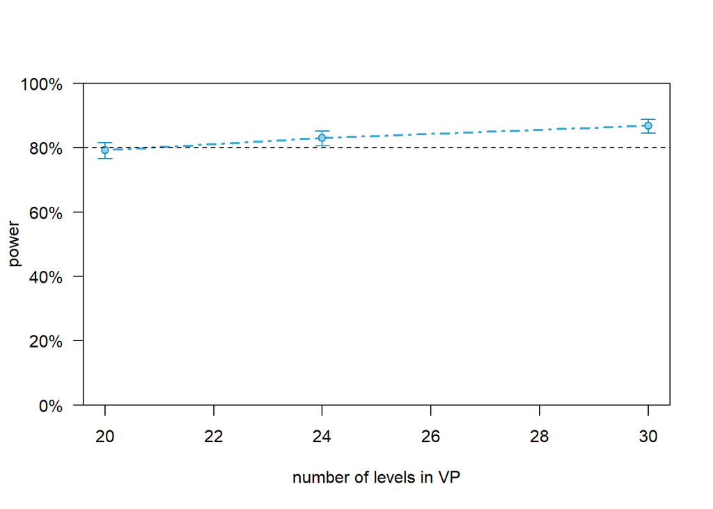

```r
plot(pc_lmm2_log)
```

# 5) Power analyses at a smaller effect size

*Model 2: Linear model, categorical predictor, log-transformed RT data* 30 VP

```r
# set fixed effect
fixef(lmm1_30_log)["Pos.L"] <- 0.042

# Power analysis
(PowerLMM1_log_30_eff0.04 <- powerSim(lmm1_30_log, test=fixed("Pos.L","t"), nsim = 1000)) # increase to nsim > 1000 for real test
```

[output not shown]

[output not shown]

[output not shown]

[output not shown]

[output not shown]

[output not shown]

[output not shown]

[output not shown]

[output not shown]

[output not shown]

[output not shown]

[output not shown]

[output not shown]

[output not shown]

[output not shown]

[output not shown]

[output not shown]

[output not shown]

[output not shown]

[output not shown]

[output not shown]

[output not shown]

[output not shown]

[output not shown]

[output not shown]

[output not shown]

[output not shown]

[output not shown]

[output not shown]

[output not shown]

[output not shown]

[output not shown]

[output not shown]

[output not shown]

[output not shown]

[output not shown]

[output not shown]

[output not shown]

[output not shown]

[output not shown]

[output not shown]

[output not shown]

[output not shown]

[output not shown]

[output not shown]

[output not shown]

[output not shown]

[output not shown]

[output not shown]

[output not shown]

[output not shown]

[output not shown]

[output not shown]

[output not shown]

[output not shown]

[output not shown]

[output not shown]

[output not shown]

[output not shown]

```
## Power for predictor 'Pos.L', (95% confidence interval):
##       85.10% (82.74, 87.25)
##
## Test: t-test with Satterthwaite degrees of freedom (package lmerTest)
##       Effect size for Pos.L is 0.042
##
## Based on 1000 simulations, (1 warning, 0 errors)
## alpha = 0.05, nrow = 3305
##
## Time elapsed: 0 h 5 m 7 s
```

```r
lastResult()$warnings
```

```
##     stage index                                                       message
## 1 Testing   512 Model failed to converge with 1 negative eigenvalue: -6.6e+01
```

```r
lastResult()$errors
```

```
## [1] stage   index   message
## <0 rows> (or 0-length row.names)
```

*Model 5: Linear model, continuous predictor, log-transformed RT data*

```r
# set fixed effect
fixef(lmm2_30_log)["Pos.c"] <-0.013 # instead of 0.01456741

# Power analysis
(PowerLMM2_log_30_eff0.013 <- powerSim(lmm2_30_log, test=fixed("Pos.c","t"), nsim = 1000)) # increase to nsim > 1000 for real test
```

[output not shown]

[output not shown]

[output not shown]

[output not shown]

[output not shown]

[output not shown]

[output not shown]

[output not shown]

[output not shown]

[output not shown]

[output not shown]

[output not shown]

[output not shown]

[output not shown]

[output not shown]

[output not shown]

[output not shown]

[output not shown]

[output not shown]

[output not shown]

[output not shown]

[output not shown]

[output not shown]

[output not shown]

[output not shown]

[output not shown]

[output not shown]

[output not shown]

[output not shown]

[output not shown]

[output not shown]

[output not shown]

[output not shown]

[output not shown]

[output not shown]

[output not shown]

[output not shown]

[output not shown]

[output not shown]

[output not shown]

[output not shown]

[output not shown]

[output not shown]

[output not shown]

[output not shown]

[output not shown]

[output not shown]

[output not shown]

[output not shown]

[output not shown]

[output not shown]

[output not shown]

[output not shown]

[output not shown]

[output not shown]

[output not shown]

[output not shown]

[output not shown]

[output not shown]

[output not shown]

[output not shown]

[output not shown]

[output not shown]

[output not shown]

[output not shown]

[output not shown]

[output not shown]

[output not shown]

[output not shown]

[output not shown]

[output not shown]

[output not shown]

[output not shown]

[output not shown]

[output not shown]

```
## Power for predictor 'Pos.c', (95% confidence interval):
##       82.80% (80.32, 85.09)
##
## Test: t-test with Satterthwaite degrees of freedom (package lmerTest)
##       Effect size for Pos.c is 0.013
##
## Based on 1000 simulations, (1 warning, 0 errors)
## alpha = 0.05, nrow = 3305
##
## Time elapsed: 0 h 5 m 30 s
```

```r
lastResult()$warnings
```

```
##     stage index                                                       message
## 1 Testing   592 Model failed to converge with 1 negative eigenvalue: -3.0e+00
```

```r
lastResult()$errors
```

```
## [1] stage   index   message
## <0 rows> (or 0-length row.names)
```

# write results

```r
# powersim_results_cont <- rbind(summary(PowerLMM1),
#                           summary(powersim_24_cont_log),
#                           summary(powersim_40_cont_log_015),
#                           summary(powersim_24_cont_log_015),
#                           summary(powersim_40_cont),
#                           summary(powersim_24_cont),
#                           summary(powersim_40_cont_18ms),
#                           summary(powersim_24_cont_18ms),
#                           summary(powersim_30_cont_18ms))
#
# powersim_results_cont <- cbind(powersim_results_cont, n = c(40,24,40,24,40,24,40,24,30), RT_transform = c("log","log","log","log","no","no","no","no","no"),Effect = c("0.031","0.031","0.015","0.015","32.2ms","32.2ms","18ms","18ms","18ms"))
#
# write.table(powersim_results_cont, "powersim_results_cont.csv", append = FALSE, sep = ";", row.names = FALSE, col.names = TRUE)
```